# Assignment 3

#### Kevin Francis

**Q2**: Develop a hypothetical set of sample training data or collect/produce a sample set of training data of a supervised learning problem and train a simple artificial neural network (ANN) in a simulation environment using the data. Show the learned weights for different accuracy levels. Then, show results for testing the ANN.

**Q3**: Develop a hypothetical set of sample training data or collect/produce a sample set of training data of an unsupervised learning problem. In a simulation environment, categorize the data into two clusters (K=2) following the K-mean clustering method. Increase the K values such as K=3, 4, and based on the simulation results and on other criteria select the best K value among all K values for the dataset. What are the advantages if you perform clustering with the best/optimum K value?

```python
#Importing default and needed libraries
import numpy as np
import matplotlib.pyplot as plt
import seaborn as sns; sns.set(style = 'whitegrid')
from sklearn import datasets
from sklearn.cluster import KMeans
from sklearn.metrics.pairwise import pairwise_distances_argmin
from sklearn.metrics import silhouette_score
import tensorflow as tf
tf.get_logger().setLevel(3)
%matplotlib inline
```

## Q2

For this first part I am going to be using the same data that I used for the last assignment. This is a randomly generated set of data with labels for supervised learning.

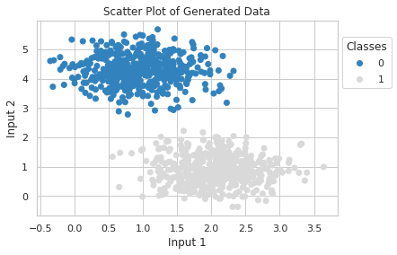

```python
# Generating grouped data
x, y = datasets.make_blobs(n_samples=1000, centers=2, random_state=0, cluster_std=0.5)
# Splitting the training and testing data
half = int(len(x) / 2)
train_x = x[:half]
test_x = x[half:]
train_y = y[:half]
test_y = y[half:]
# Creating a scatter plot to look at all of the the initial data
fig, ax = plt.subplots()
scatter = ax.scatter(x[:, 0], x[:, 1], c = y, cmap = 'tab20c')
ax.set(xlabel='Input 1', ylabel='Input 2', title = 'Scatter Plot of Generated Data')
ax.legend(*scatter.legend_elements(), loc="lower left", title="Classes", bbox_to_anchor=(1, .63));
```

First I am going to explain the tensorflow model below and some of the parameters used.

The model below is sequential. This just means that the data flows through the model sequentially, meaning one layer at a time in the order they are listed below. The first layer is using a rectifier (relu) activation function while the second has a sigmoid activation function. Below is the mathematical expression for those two functions.

Relu: $f(x) = max(0,x)$

Sigmoid: $f(x) = \frac{e^x}{e^x + 1}$

Now for the parameters included when compiling the model. First we have the loss, this is used to determine the error between the predicted outputs and the actual outputs. For this I choose the cross-entropy loss function. Next is the optimizer, this is something that is used to try and minimize the loss. In this case, the algorithm I chose was adam. It optimized the learning rate to better the weight predictions. Lastly we have the metrics, this is similar to the loss function, however it is not used when training the model. I picked the accuracy metric, which will tell us how often the correct classification was predicted. Two remaining things to explain are the parameters in fitting the model. Those two are below.

Epoch - When an entire dataset has passed through the neural network once.

batch_size - Total number of training examples present in a single batch.

```python
init_weights = []
final_weights = []
pred = []
acc = []
for i in range(1,6):
    model = tf.keras.Sequential()
    model.add(tf.keras.layers.Dense(50, input_dim=2, activation='relu', name='L1'))
    model.add(tf.keras.layers.Dense(1, activation='sigmoid', name='Output'))
    # Initial weights
    init_weights.append(model.get_weights())
    model.compile(loss='binary_crossentropy', optimizer=tf.keras.optimizers.Adam(learning_rate=0.001), metrics=['accuracy'])
    model.fit(tf.convert_to_tensor(train_x), tf.convert_to_tensor(train_y), epochs=10, batch_size=10, verbose=0);
    # Final weights
    final_weights.append(model.get_weights())
    pred.append(model.predict(tf.convert_to_tensor(test_x)))
    acc.append(model.evaluate(tf.convert_to_tensor(test_x), tf.convert_to_tensor(test_y)))
pred = np.around(pred)
```

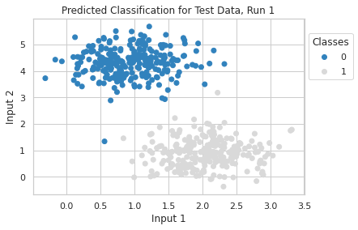

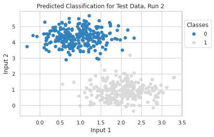

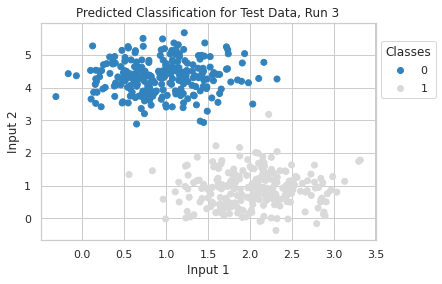

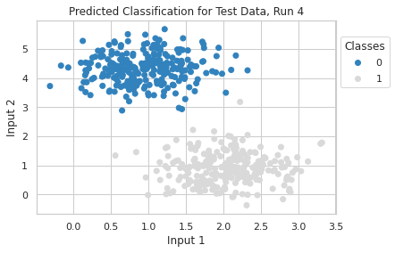

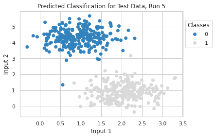

```python
for i in range(len(pred)):
    fig, ax = plt.subplots()
    scatter = ax.scatter(test_x[:, 0], test_x[:, 1], c = pred[i], cmap = 'tab20c')
    ax.set(xlabel='Input 1', ylabel='Input 2', title = 'Predicted Classification for Test Data, Run ' + str(i + 1))
    ax.legend(*scatter.legend_elements(), loc="lower left", title="Classes", bbox_to_anchor=(1, .63));
```

Since the dataset is large and there are two layers in the neural network, I will display the initial and final weights at the end of the project.

## Q3

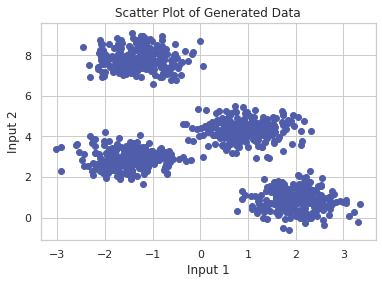

```python
# Generating new data for k-means, will not be using y for this part because the data needs to be unlabeled
x, y = datasets.make_blobs(n_samples=1000, centers=4, random_state=0, cluster_std=.5)
# Creating a scatter plot to look at all of the the initial data
fig, ax = plt.subplots()
scatter = ax.scatter(x[:, 0], x[:, 1], color = '#505DAB')
ax.set(xlabel='Input 1', ylabel='Input 2', title = 'Scatter Plot of Generated Data');
```

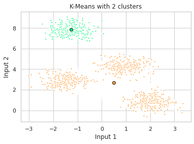

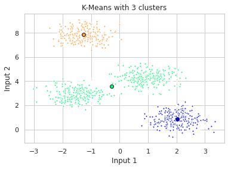

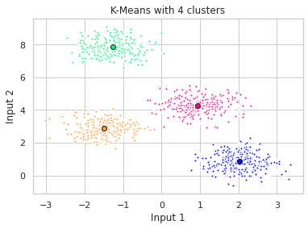

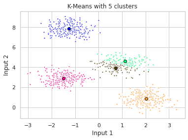

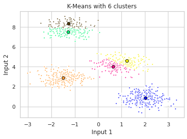

```python
sil = []
sse = []
for i in range(2,7):
    kmeans = KMeans(n_clusters=i, random_state=0).fit(x)
    #print(len(kmeans.labels_))
    kmeans_cluster_centers = kmeans.cluster_centers_
    kmeans_labels = pairwise_distances_argmin(x, kmeans_cluster_centers)
    sil.append(silhouette_score(x, kmeans.labels_, metric = 'euclidean'))
    pred_clusters = kmeans.predict(x)
    curr_sse = 0
    # calculate square of Euclidean distance of each point from its cluster center and add to current WSS
    for j in range(len(x)):
        curr_center = kmeans_cluster_centers[pred_clusters[j]]
        curr_sse += (x[j, 0] - curr_center[0]) ** 2 + (x[j, 1] - curr_center[1]) ** 2

    sse.append(curr_sse)
    fig, ax = plt.subplots()
    colors = ['#06F979', '#FF9C34', '#060DF9', '#F90687', '#523B0A', '#f9f206']
    for k, col in zip(range(i), colors):
        my_members = kmeans_labels == k
        cluster_center = kmeans_cluster_centers[k]
        ax.plot(x[my_members, 0], x[my_members, 1], 'w',
            markerfacecolor=col, marker='.')
        ax.plot(cluster_center[0], cluster_center[1], 'o', markerfacecolor=col,
            markeredgecolor='k', markersize=6)
    ax.set(xlabel='Input 1', ylabel='Input 2', title = 'K-Means with ' + str(i) + ' clusters');
```

Above we can see the data grouped into clusters ranging from 2 to 6. Now let's try and see which value of k is the optimal. To do this we will look at two different plots. The first will be an elbow plot. This shows the number of clusters vs the sum of squared errors. Where the plot starts to converge is the elbow and optimal number of clusters. Next we will look at the silhouette score. This measures how similar a point is within its own cluster when compared to other clusters. The euclidean distance is used at the metric for the silhouette score.

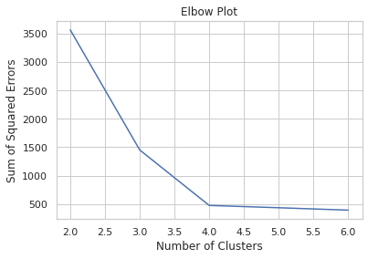

```python
plt.plot(np.arange(2, len(sse)+2), sse)
plt.title('Elbow Plot')
plt.xlabel('Number of Clusters')
plt.ylabel('Sum of Squared Errors');
```

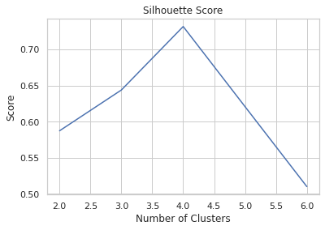

```python
plt.plot(np.arange(2, len(sil)+2), sil)
plt.title('Silhouette Score')
plt.xlabel('Number of Clusters')
plt.ylabel('Score');
```

The two plots above show that the optimal number of clusters for this data is 4. It is where the elbow plot converges and the silhouette score peaks. It is important to use the optimal k value when forming clusters because it minimizes the error. When the error is minimized more confidence can be placed in the classified or grouped values.

Below is the huge list of weights for the neural network in the first problem.

```python
for i in range(len(acc)):
    print('For the model with accuracy ' + "{:.2f}".format(acc[i][1] * 100) + ', the initail and final weights for the first layer are: ')
    print('Initial Weights: \n', init_weights[i][0])
    print('Final Weights: \n', final_weights[i][0])
    print('Second Layer ')
    print('Initial Weights: \n', init_weights[i][2])
    print('Final Weights: \n', final_weights[i][2])
```

```
For the model with accuracy 99.60, the initail and final weights for the first layer are:
Initial Weights:
 [[-0.16293468  0.30462313  0.16138023 -0.2994429   0.09438515  0.03490642
  -0.12511063 -0.09837697 -0.19181302 -0.21986927 -0.27314892  0.09008765
   0.02112848 -0.01008204 -0.26749903  0.18959624  0.27543128  0.28122377
   0.15751407 -0.17261891  0.2605018  -0.23941639 -0.27961028  0.17611194
  -0.30271095  0.2971282   0.22979242 -0.12549499  0.32276255 -0.10428107
   0.27200717 -0.05614287  0.09265429 -0.32819578  0.16609424  0.0218704
   0.05228513 -0.15242763  0.31579006  0.19170368  0.28668773  0.09434903
   0.2544623  -0.07495075  0.28329825 -0.23135838 -0.09999613 -0.20984983
   0.28336668 -0.26168987]
 [ 0.21809393  0.00902477  0.07460767 -0.23418425 -0.12821695 -0.30280662
  -0.29490772 -0.17677872  0.3070969   0.14022502 -0.08451343  0.23904854
  -0.23261803 -0.31340057 -0.15344813  0.01280028  0.29318553 -0.25367427
   0.14984202  0.06876385 -0.1773581  -0.02291051  0.22427738 -0.30248988
   0.00843006 -0.01292396 -0.20484947  0.1532895  -0.31494555 -0.08467782
  -0.27342677 -0.09023586  0.32070094  0.1533866  -0.0495967   0.28066772
   0.2685486   0.17546082 -0.28261515 -0.32971987  0.2831589  -0.11516204
   0.04116923 -0.25655448 -0.20925547  0.12093601  0.2537067  -0.08065075
  -0.16803263 -0.04382914]]
Final Weights:
 [[-2.6713753e-01  5.3949183e-01  3.1450012e-01 -2.9944289e-01
   2.7218977e-01  3.6919034e-01 -1.2511063e-01 -9.8376974e-02
  -2.9593772e-01 -2.8310654e-01 -2.7314892e-01  2.1619308e-01
  -2.0658849e-04 -2.5438963e-02 -2.6749903e-01  6.1451029e-02
   3.8566068e-01  5.0721085e-01 -2.5779419e-03 -2.0487666e-01
   1.5605292e-01 -2.3941639e-01 -2.9723853e-01  3.7704584e-01
  -2.8168878e-01  4.8870552e-01  4.5035523e-01 -1.9511116e-01
   3.0809477e-01 -1.0428107e-01  4.5088410e-01 -5.6142867e-02
  -5.6187540e-02 -2.4413779e-01  3.3295572e-01 -1.7009100e-01
  -9.8500594e-02 -1.9368452e-01  2.3593901e-01  4.0836149e-01
   4.2022800e-01  4.4024091e-02  1.2935857e-01 -7.4950755e-02
   4.5735946e-01 -2.5993362e-01 -1.9884957e-01 -2.0984983e-01
   5.4734039e-01 -2.6168987e-01]
 [ 1.0493873e-01 -1.7413020e-01 -7.3078729e-02 -2.3418425e-01
  -1.2638053e-01 -1.8411833e-01 -2.9490772e-01 -1.7677872e-01
   5.8700705e-01  5.6396265e-02 -8.4513426e-02  1.1580423e-01
  -2.1819147e-01 -2.9564717e-01 -1.5344813e-01  1.3889772e-01
   1.8822832e-01 -2.0342225e-01  3.1510717e-01  1.9397821e-02
  -2.6903734e-01 -2.2910506e-02  5.2598894e-01 -1.7049302e-01
```

[output cut: 663 more lines]

```
 [ 3.41133922e-01]
 [-2.28957385e-01]
 [-3.56567532e-01]
 [-4.02423859e-01]
 [-1.67060271e-01]
 [ 1.63390994e-01]
 [ 5.50637901e-01]
 [ 5.28008044e-02]
 [ 3.08779955e-01]
 [ 3.34684759e-01]
 [ 5.90842329e-02]
 [ 1.66070029e-01]
 [-3.75268191e-01]
 [-1.14261627e-01]
 [-2.11106122e-01]]
```